# PASIAS Chapter 14

Mohammad Amr Khan

# Chapter 14 Regression

## Packages

```r
library(tidyverse)
library(broom)
library(MASS)
```

## 14.1 Rainfall in California

The data in link are rainfall and other measurements for 30 weather stations in California. Our aim is to understand how well the annual rainfall at these stations (measured in inches) can be predicted from the other measurements, which are the altitude (in feet above sea level), the latitude (degrees north of the equator) and the distance from the coast (in miles).

```r
rain_url="http://www.utsc.utoronto.ca/~butler/c32/calirain.txt"
rains=read_table2(rain_url)
```

```r
rains
```

| station | rainfall | altitude | latitude | fromcoast |
| --- | --- | --- | --- | --- |
| Eureka | 39.57 | 43 | 40.8 | 1 |
| RedBluff | 23.27 | 341 | 40.2 | 97 |
| Thermal | 18.20 | 4152 | 33.8 | 70 |
| FortBragg | 37.48 | 74 | 39.4 | 1 |
| SodaSprings | 49.26 | 6752 | 39.3 | 150 |
| SanFrancisco | 21.82 | 52 | 37.8 | 5 |
| Sacramento | 18.07 | 25 | 38.5 | 80 |
| SanJose | 14.17 | 95 | 37.4 | 28 |
| GiantForest | 42.63 | 6360 | 36.6 | 145 |
| Salinas | 13.85 | 74 | 36.7 | 12 |

[output cut: 20 more lines]

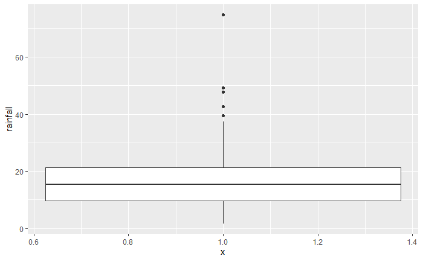

```r
ggplot(rains, aes(y=rainfall, x=1)) + geom_boxplot()
```

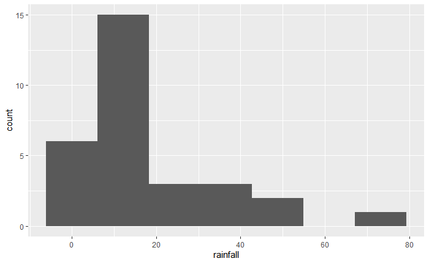

```r
ggplot(rains, aes(x=rainfall))+geom_histogram(bins=7)
```

There is a right skew

```r
rains %>% filter(rainfall>60)
```

| station | rainfall | altitude | latitude | fromcoast |
| --- | --- | --- | --- | --- |
| CrescentCity | 74.87 | 35 | 41.7 | 1 |

```r
rains %>% filter(rainfall<2)
```

| station | rainfall | altitude | latitude | fromcoast |
| --- | --- | --- | --- | --- |
| DeathValley | 1.66 | -178 | 36.5 | 194 |

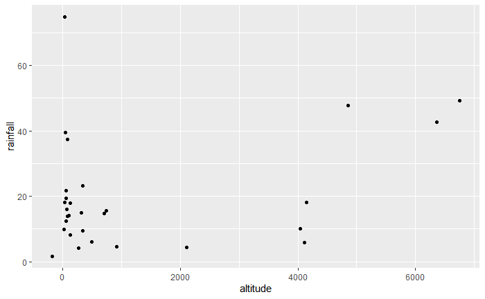

```r
ggplot(rains,aes(y=rainfall,x=altitude))+geom_point()
```

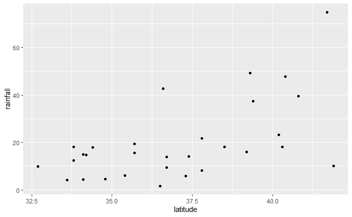

```r
ggplot(rains,aes(y=rainfall,x=latitude))+geom_point()
```

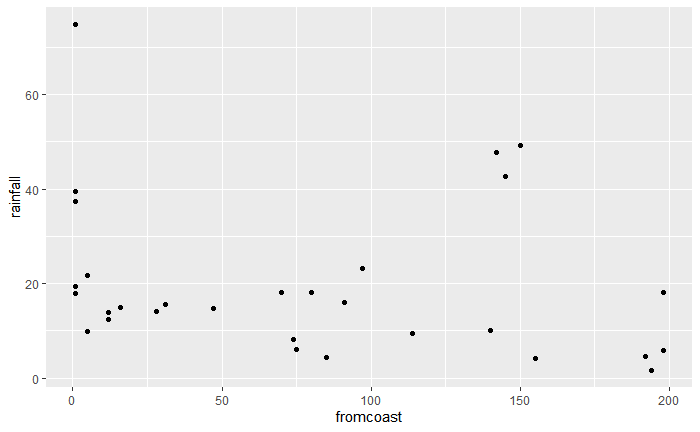

```r
ggplot(rains,aes(y=rainfall,x=fromcoast))+geom_point()
```

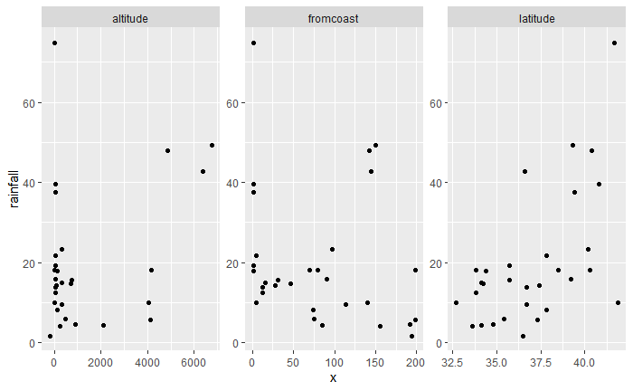

```r
rains %>%
  pivot_longer(altitude:fromcoast, names_to="xname",values_to="x") %>%
  ggplot(aes(x=x,y=rainfall))+geom_point()+
  facet_wrap(~xname,scales="free")
```

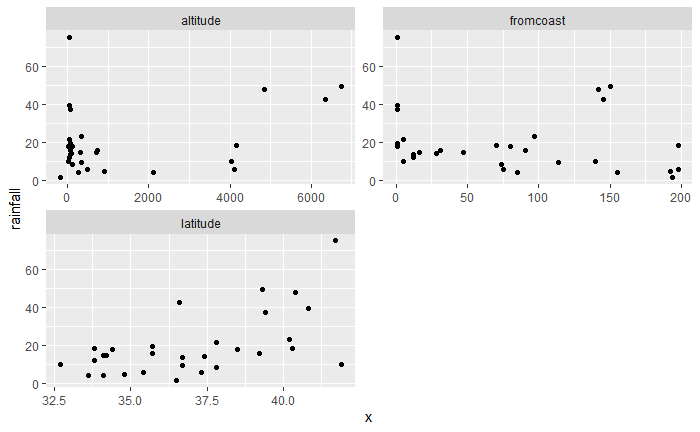

```r
rains %>%
  pivot_longer(altitude:fromcoast, names_to="xname",values_to="x") %>%
  ggplot(aes(x=x,y=rainfall))+geom_point()+
  facet_wrap(~xname,scales="free",ncol=2)
```

altitude: not much of anything. The stations near sea level have rainfall all over the place, though the three highest-altitude stations have the three highest rainfalls apart from Crescent City.

latitude: there is a definite upward trend here, in that stations further north (higher latitude) are likely to have a higher rainfall. I’d call this trend linear (or, not obviously curved), though the two most northerly stations have one higher and one much lower rainfall than you’d expect.

fromcoast: this is a weak downward trend, though the trend is spoiled by those three stations about 150 miles from the coast that have more than 40 inches of rainfall.

```r
rainfall.1=lm(rainfall~latitude,data=rains)
summary(rainfall.1)
```

```
Call:
lm(formula = rainfall ~ latitude, data = rains)

Residuals:
    Min      1Q  Median      3Q     Max
-27.297  -7.956  -2.103   6.082  38.262

Coefficients:
             Estimate Std. Error t value Pr(>|t|)
(Intercept) -113.3028    35.7210  -3.172  0.00366 **
latitude       3.5950     0.9623   3.736  0.00085 ***
---
Signif. codes:  0 ‘***’ 0.001 ‘**’ 0.01 ‘*’ 0.05 ‘.’ 0.1 ‘ ’ 1

Residual standard error: 13.82 on 28 degrees of freedom
Multiple R-squared:  0.3326,    Adjusted R-squared:  0.3088
F-statistic: 13.96 on 1 and 28 DF,  p-value: 0.0008495
```

Both intercept and gradient p-values are signficant

R-squares is however low 33%

## 14.4 Facebook friends and grey matter

Is there a relationship between the number of Facebook friends a person has, and the density of grey matter in the areas of the brain associated with social perception and associative memory? To find out, a 2012 study measured both of these variables for a sample of 40 students at City University in London (England). The data are at link. The grey matter density is on a z-score standardized scale. The values are separated by tabs.

```r
my_url <- "http://www.utsc.utoronto.ca/~butler/c32/facebook.txt"
fb <- read_tsv(my_url)
```

```r
fb
```

| GMdensity | FBfriends |
| --- | --- |
| -1.8 | 23 |
| 0.1 | 35 |
| -1.2 | 80 |
| -0.4 | 110 |
| -0.9 | 120 |
| -2.1 | 140 |
| -1.5 | 168 |
| 0.5 | 132 |
| 0.6 | 154 |
| -0.5 | 241 |

[output cut: 30 more lines]

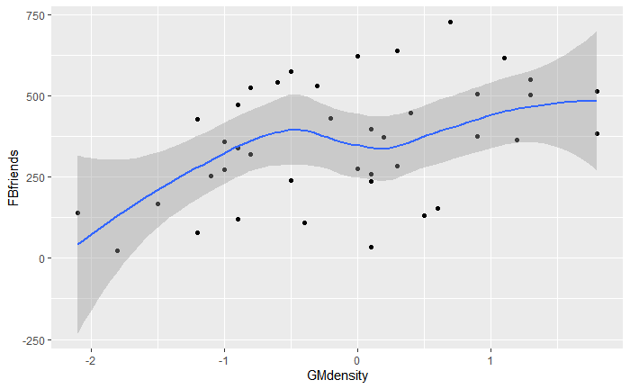

```r
ggplot(fb, aes(x = GMdensity, y = FBfriends)) + geom_point() + geom_smooth()
```

I’d say there seems to be a weak, upward, apparently linear trend. The points are not especially close to the trend, so I don’t think there’s any justification for calling this other than “weak”.

```r
fb.1 <- lm(FBfriends ~ GMdensity, data = fb)
summary(fb.1)
```

```
Call:
lm(formula = FBfriends ~ GMdensity, data = fb)

Residuals:
    Min      1Q  Median      3Q     Max
-339.89 -110.01   -5.12   99.80  303.64

Coefficients:
            Estimate Std. Error t value Pr(>|t|)
(Intercept)   366.64      26.35  13.916  < 2e-16 ***
GMdensity      82.45      27.58   2.989  0.00488 **
---
Signif. codes:  0 ‘***’ 0.001 ‘**’ 0.01 ‘*’ 0.05 ‘.’ 0.1 ‘ ’ 1

Residual standard error: 165.7 on 38 degrees of freedom
Multiple R-squared:  0.1904,    Adjusted R-squared:  0.1691
F-statistic: 8.936 on 1 and 38 DF,  p-value: 0.004882
```

The P-value of the slope is 0.005, which is less than 0.05. Therefore the slope is significantly different from zero. That means that the number of Facebook friends really does depend on the grey matter density, for the whole population of interest and not just the 40 students observed here

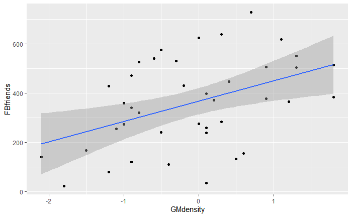

```r
ggplot(fb, aes(x = GMdensity, y = FBfriends)) + geom_point() +
  geom_smooth(method = "lm")
```

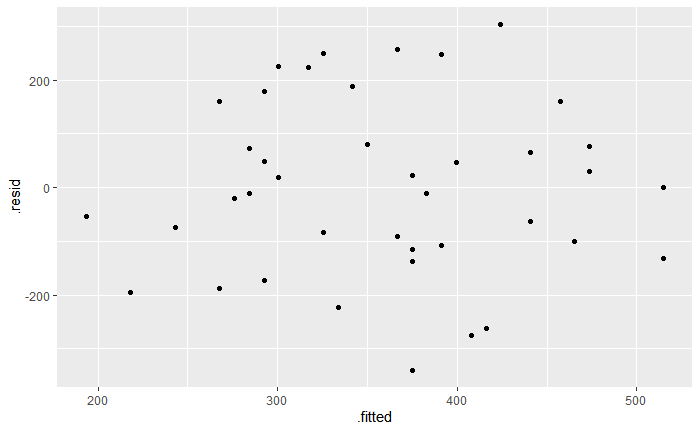

```r
ggplot(fb.1, aes(x = .fitted, y = .resid)) + geom_point()
```

## 14.5 Endogenous Nitrogen Excretion in Carp

A paper in Fisheries Science reported on variables that affect “endogenous nitrogen excretion” or ENE in carp raised in Japan. A number of carp were divided into groups based on body weight, and each group was placed in a different tank. The mean body weight of the carp placed in each tank was recorded. The carp were then fed a protein-free diet three times daily for a period of 20 days. At the end of the experiment, the amount of ENE in each tank was measured, in milligrams of total fish body weight per day. (Thus it should not matter that some of the tanks had more fish than others, because the scaling is done properly.)

The text is stored in a text file that is space delimited

```r
carp_url <- "http://www.utsc.utoronto.ca/~butler/c32/carp.txt"
carp_data <- read_delim(carp_url, " ")
```

Shows that there are three columns - tank, weight and nitrogen content

```r
carp_data
```

| tank | bodyweight | ENE |
| --- | --- | --- |
| 1 | 11.7 | 15.3 |
| 2 | 25.3 | 9.3 |
| 3 | 90.2 | 6.5 |
| 4 | 213.0 | 6.0 |
| 5 | 10.2 | 15.7 |
| 6 | 17.6 | 10.0 |
| 7 | 32.6 | 8.6 |
| 8 | 81.3 | 6.4 |
| 9 | 141.5 | 5.6 |
| 10 | 285.7 | 6.0 |

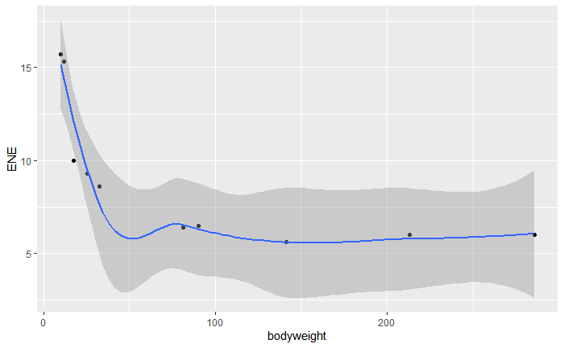

```r
ggplot(carp_data, aes(y=ENE, x=bodyweight)) + geom_point() + geom_smooth()
```

Higher ENE concentration leads to a lower bodyweight

```r
carp.1 <- lm(ENE ~ bodyweight, data=carp_data)
summary(carp.1)
```

```
Call:
lm(formula = ENE ~ bodyweight, data = carp_data)

Residuals:
   Min     1Q Median     3Q    Max
-2.800 -1.957 -1.173  1.847  4.572

Coefficients:
            Estimate Std. Error t value Pr(>|t|)
(Intercept) 11.40393    1.31464   8.675 2.43e-05 ***
bodyweight  -0.02710    0.01027  -2.640   0.0297 *
---
Signif. codes:  0 ‘***’ 0.001 ‘**’ 0.01 ‘*’ 0.05 ‘.’ 0.1 ‘ ’ 1

Residual standard error: 2.928 on 8 degrees of freedom
Multiple R-squared:  0.4656,    Adjusted R-squared:  0.3988
F-statistic: 6.971 on 1 and 8 DF,  p-value: 0.0297
```

R-squared value is 0.47 which is low

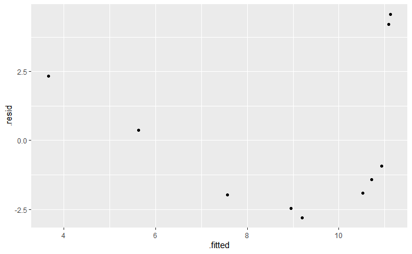

```r
ggplot(carp.1, aes(y=.resid, x=.fitted)) + geom_point()
```

There is a trend in the residuals so a linear model is not appropriate

```r
carp.2 <- lm(ENE ~ bodyweight + I(bodyweight^2), data=carp_data)
summary(carp.2)
```

```
Call:
lm(formula = ENE ~ bodyweight + I(bodyweight^2), data = carp_data)

Residuals:
    Min      1Q  Median      3Q     Max
-2.0834 -1.7388 -0.5464  1.3841  2.9976

Coefficients:
                  Estimate Std. Error t value Pr(>|t|)
(Intercept)     13.7127373  1.3062494  10.498 1.55e-05 ***
bodyweight      -0.1018390  0.0288109  -3.535  0.00954 **
I(bodyweight^2)  0.0002735  0.0001016   2.692  0.03101 *
---
Signif. codes:  0 ‘***’ 0.001 ‘**’ 0.01 ‘*’ 0.05 ‘.’ 0.1 ‘ ’ 1

Residual standard error: 2.194 on 7 degrees of freedom
Multiple R-squared:  0.7374,    Adjusted R-squared:  0.6624
F-statistic: 9.829 on 2 and 7 DF,  p-value: 0.009277
```

R-squared has increased but this could be since we added another parameter. But adjusted R-squared also shows the increase

P value for squared bodyweight is 0.031 which is significant

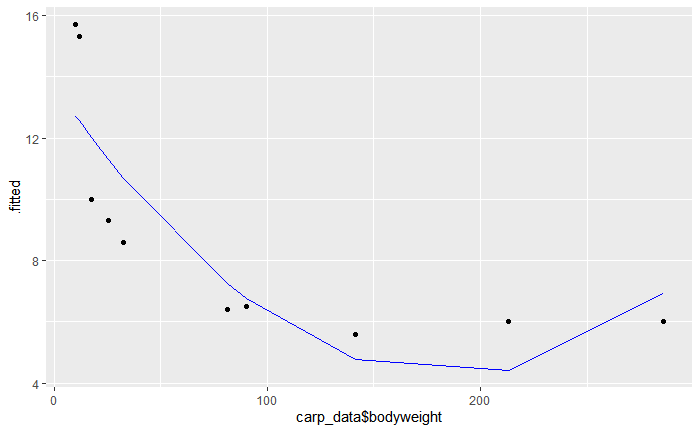

```r
ggplot(carp.2, aes(y=.fitted, x=carp_data$bodyweight), color="blue") + geom_line(color="blue") +
         geom_point(data=carp_data, aes(x=bodyweight, y = ENE))
```

```r
install.packages("broom")
```

```
Error in install.packages : Updating loaded packages
```

```r
carp.2a <- augment(carp.2, carp_data)
carp.2a
```

| tank | bodyweight | ENE | .fitted | .resid | .hat | .sigma | .cooksd | .std.resid |
| --- | --- | --- | --- | --- | --- | --- | --- | --- |
| 1 | 11.7 | 15.3 | 12.558657 | 2.7413428 | 0.2392022 | 1.992810 | 0.21499558 | 1.4322784 |
| 2 | 25.3 | 9.3 | 11.311261 | -2.0112607 | 0.1629840 | 2.193651 | 0.06514640 | -1.0018443 |
| 3 | 90.2 | 6.5 | 6.751885 | -0.2518851 | 0.2396677 | 2.367208 | 0.00182089 | -0.1316435 |
| 4 | 213.0 | 6.0 | 4.428445 | 1.5715555 | 0.3246419 | 2.237874 | 0.12169479 | 0.8714880 |
| 5 | 10.2 | 15.7 | 12.702432 | 2.9975680 | 0.2511559 | 1.902036 | 0.27859605 | 1.5785999 |
| 6 | 17.6 | 10.0 | 12.005083 | -2.0050832 | 0.1993691 | 2.186473 | 0.08656338 | -1.0212098 |
| 7 | 32.6 | 8.6 | 10.683427 | -2.0834268 | 0.1425478 | 2.184918 | 0.05826041 | -1.0253497 |
| 8 | 81.3 | 6.4 | 7.240829 | -0.8408294 | 0.2112076 | 2.338418 | 0.01661407 | -0.4314448 |
| 9 | 141.5 | 5.6 | 4.778159 | 0.8218410 | 0.3546865 | 2.333053 | 0.03982493 | 0.4662310 |
| 10 | 285.7 | 6.0 | 6.939822 | -0.9398221 | 0.8745372 | 2.108136 | 3.39715895 | -1.2091687 |

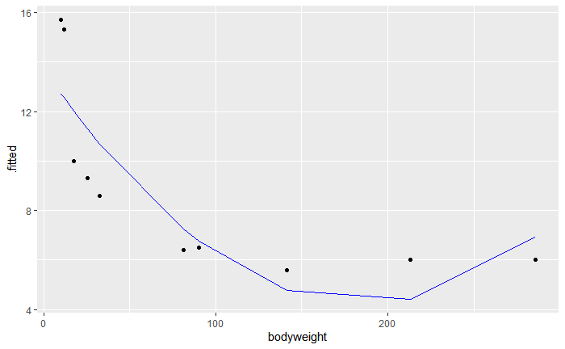

```r
g <- ggplot(carp.2a, aes(x = bodyweight, y = .fitted)) +
  geom_line(colour = "blue") +
  geom_point(aes(y = ENE))
g
```

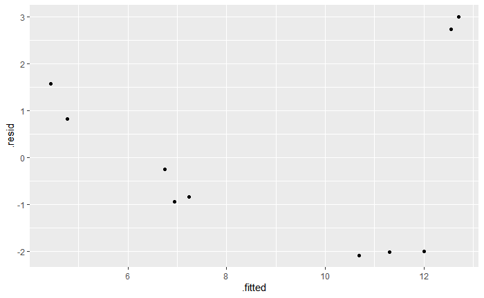

```r
ggplot(carp.2, aes(y=.resid, x=.fitted)) + geom_point()
```

Still a curve

```r
carp.3 <- lm(ENE ~ I(1 / bodyweight), data = carp_data)
summary(carp.3)
```

```
Call:
lm(formula = ENE ~ I(1/bodyweight), data = carp_data)

Residuals:
     Min       1Q   Median       3Q      Max
-1.29801 -0.12830  0.04029  0.26702  0.91707

Coefficients:
                Estimate Std. Error t value Pr(>|t|)
(Intercept)       5.1804     0.2823   18.35 8.01e-08 ***
I(1/bodyweight) 107.6690     5.8860   18.29 8.21e-08 ***
---
Signif. codes:  0 ‘***’ 0.001 ‘**’ 0.01 ‘*’ 0.05 ‘.’ 0.1 ‘ ’ 1

Residual standard error: 0.6121 on 8 degrees of freedom
Multiple R-squared:  0.9766,    Adjusted R-squared:  0.9737
F-statistic: 334.6 on 1 and 8 DF,  p-value: 8.205e-08
```

Higher R squared vlaue and Is signficant.

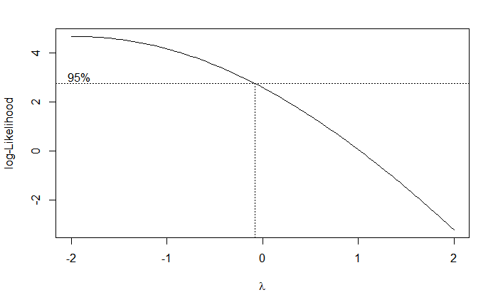

```r
boxcox(ENE ~ bodyweight, data=carp_data)
```

## 14.10 Crickets Revisited

```r
my_url <- "http://www.utsc.utoronto.ca/~butler/c32/crickets2.csv"
crickets <- read_csv(my_url)
```

```r
crickets
```

| species | temperature | pulse_rate |
| --- | --- | --- |
| exclamationis | 20.8 | 67.9 |
| exclamationis | 20.8 | 65.1 |
| exclamationis | 24.0 | 77.3 |
| exclamationis | 24.0 | 78.7 |
| exclamationis | 24.0 | 79.4 |
| exclamationis | 24.0 | 80.4 |
| exclamationis | 26.2 | 85.8 |
| exclamationis | 26.2 | 86.6 |
| exclamationis | 26.2 | 87.5 |
| exclamationis | 26.2 | 89.1 |

[output cut: 21 more lines]

```r
t.test(pulse_rate ~ species, data = crickets)
```

```
    Welch Two Sample t-test

data:  pulse_rate by species
t = 5.2236, df = 28.719, p-value = 1.401e-05
alternative hypothesis: true difference in means is not equal to 0
95 percent confidence interval:
 14.08583 32.22677
sample estimates:
mean in group exclamationis        mean in group niveus
                   85.58571                    62.42941
```

```r
pulse.0 <- lm(pulse_rate ~ species, data = crickets)
summary(pulse.0)
```

```
Call:
lm(formula = pulse_rate ~ species, data = crickets)

Residuals:
    Min      1Q  Median      3Q     Max
-20.486  -9.458  -1.729  13.342  22.271

Coefficients:
              Estimate Std. Error t value Pr(>|t|)
(Intercept)     85.586      3.316  25.807  < 2e-16 ***
speciesniveus  -23.156      4.478  -5.171 1.58e-05 ***
---
Signif. codes:  0 ‘***’ 0.001 ‘**’ 0.01 ‘*’ 0.05 ‘.’ 0.1 ‘ ’ 1

Residual standard error: 12.41 on 29 degrees of freedom
Multiple R-squared:  0.4797,    Adjusted R-squared:  0.4617
F-statistic: 26.74 on 1 and 29 DF,  p-value: 1.579e-05
```

```r
t.test(pulse_rate ~ species, data = crickets, var.equal = T)
```

```
    Two Sample t-test

data:  pulse_rate by species
t = 5.1706, df = 29, p-value = 1.579e-05
alternative hypothesis: true difference in means is not equal to 0
95 percent confidence interval:
 13.99690 32.31571
sample estimates:
mean in group exclamationis        mean in group niveus
                   85.58571                    62.42941
```

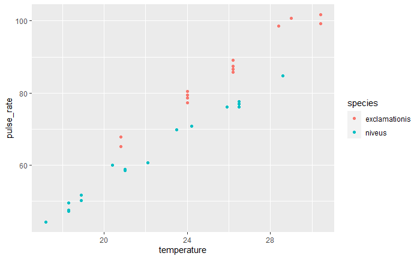

```r
ggplot(crickets, aes(x = temperature, y = pulse_rate, colour = species)) +
  geom_point()
```

```r
pulse.1 <- lm(pulse_rate ~ species + temperature, data = crickets)
summary(pulse.1)
```

```
Call:
lm(formula = pulse_rate ~ species + temperature, data = crickets)

Residuals:
    Min      1Q  Median      3Q     Max
-3.0128 -1.1296 -0.3912  0.9650  3.7800

Coefficients:
               Estimate Std. Error t value Pr(>|t|)
(Intercept)    -7.21091    2.55094  -2.827  0.00858 **
speciesniveus -10.06529    0.73526 -13.689 6.27e-14 ***
temperature     3.60275    0.09729  37.032  < 2e-16 ***
---
Signif. codes:  0 ‘***’ 0.001 ‘**’ 0.01 ‘*’ 0.05 ‘.’ 0.1 ‘ ’ 1

Residual standard error: 1.786 on 28 degrees of freedom
Multiple R-squared:  0.9896,    Adjusted R-squared:  0.9888
F-statistic:  1331 on 2 and 28 DF,  p-value: < 2.2e-16
```

```r
pulse.2 <- lm(pulse_rate ~ species * temperature, data = crickets)
summary(pulse.2)
```

```
Call:
lm(formula = pulse_rate ~ species * temperature, data = crickets)

Residuals:
    Min      1Q  Median      3Q     Max
-3.7031 -1.3417 -0.1235  0.8100  3.6330

Coefficients:
                          Estimate Std. Error t value Pr(>|t|)
(Intercept)               -11.0408     4.1515  -2.659    0.013 *
speciesniveus              -4.3484     4.9617  -0.876    0.389
temperature                 3.7514     0.1601  23.429   <2e-16 ***
speciesniveus:temperature  -0.2340     0.2009  -1.165    0.254
---
Signif. codes:  0 ‘***’ 0.001 ‘**’ 0.01 ‘*’ 0.05 ‘.’ 0.1 ‘ ’ 1

Residual standard error: 1.775 on 27 degrees of freedom
Multiple R-squared:  0.9901,    Adjusted R-squared:  0.989
F-statistic: 898.9 on 3 and 27 DF,  p-value: < 2.2e-16
```

```r
anova(pulse.1, pulse.2)
```

```
Analysis of Variance Table

Model 1: pulse_rate ~ species + temperature
Model 2: pulse_rate ~ species * temperature
  Res.Df    RSS Df Sum of Sq     F Pr(>F)
1     28 89.350
2     27 85.074  1    4.2758 1.357 0.2542
```

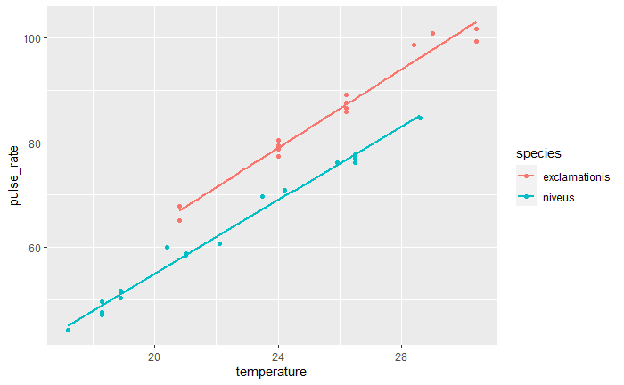

```r
ggplot(crickets, aes(x = temperature, y = pulse_rate, colour = species)) +
  geom_point() + geom_smooth(method = "lm", se = F)
```

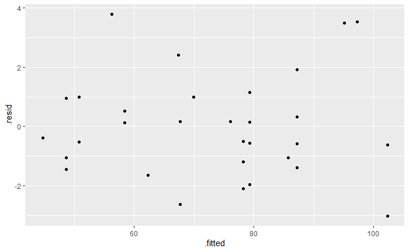

```r
ggplot(pulse.1, aes(x = .fitted, y = .resid)) + geom_point()
```

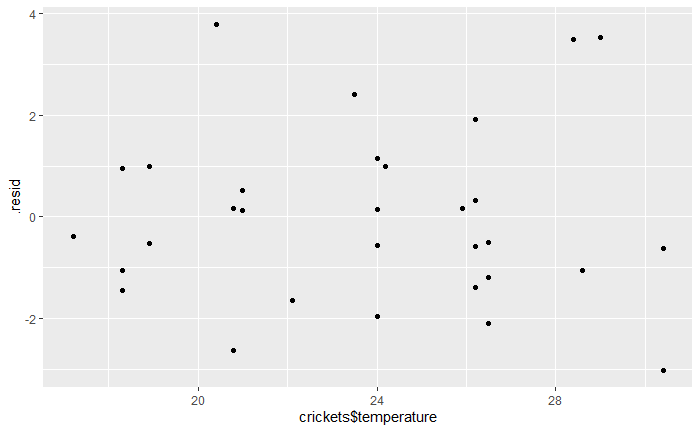

```r
ggplot(pulse.1, aes(x = crickets$temperature, y = .resid)) + geom_point()
```